# MATH1062 Statistics

Lab Week 2 - Introduction to R and Graphical Summaries

Author

Kierin Chung with scaffold and instructions from Yeeka Yau.

Published

August 11, 2025

# Welcome! 😊

Each week your MATH1062 statistics workshops will involve conceptual/theoretical questions as well as R coding questions. When you come to workshops you should expect the following:

- Engage with your peers and tutor! Many questions will require you to discuss ideas in groups and write on the whiteboards in conjunction with coding in R.

As a first introductory lab, we will explore how data visualisations can help form answers to initial research questions. We will also practice our *statistical intuition* and *data sense* by examining various data visualisations and think about how they relate to basic numerical summaries.

### Learning Outcomes covered in this lab

- **LO3**. identify appropriate methods to describe, summarise and visualise a given data set
- **LO5**. apply statistical software such as R to analyse example sets of data

### Specific lab outcomes:

- Meet new friends and have fun.
- Learn the basics of an R Quarto document.
- Be able to read in a csv file of data into an R dataframe.
- Experience some basics of data wrangling in R.
- Be able to use R to calculate basic numerical summaries and make basic data visualisations.

## Group Discussion Questions

1. Introduce yourself to your group at your table. Have each member of the group say the following three things about themselves, and write these on the board: **Name, where you are from, something you enjoy doing.**
2. Recall that the **five number summary** are the following numbers

   $$(minimum, Q1, median, Q3, maximum)$$

   Another statistic to measure “spread” of data is the **interquartile range (IQR),** which is defined to be $Q3-Q1$. How “robust” or “resistant” is IQR to outliers in quantitative data? Discuss this in your group, construct an example to support any claims.

It is robust as it is the spread of the middle 50% of the data. Therefore, it is highly robust and is similar to median whereby it is not easily affected by outliers.

### Set up and reading data into R

The first thing we usually do is import helpful packages of code called “libraries” to make our visualisations look nicer and to help with data wrangling. The libraries **ggplot2** and **dplyr** are very commonly used and included in the **tidyverse** package.

```r
# This package includes the packages ggplot and dplyr for data visualisation and manipulation
library(tidyverse)
```

### The data set

This week, we examine a data set from an in-class survey of students in introductory statistics courses at a US university. This data comes from [Datasets from the textbook: Statistics: Unlocking the power of data](https://www.lock5stat.com/datapage3e.html). We’ve chosen this data set for this lab as it contains a variety of variables for various visualisations and is easy to understand.

```r
# This code reads data from a csv file into an R data frame called "student_data"
student_data <- read.csv("/Users/kierin/MATH1062/Week2/StudentSurvey.csv")
```

#### View a “summary” of the data

```r
# This code displays a "summary" of the data
str(student_data)
```

```
'data.frame':   362 obs. of  17 variables:
 $ Year      : chr  "Senior" "Sophomore" "FirstYear" "Junior" ...
 $ Sex       : chr  "M" "F" "M" "M" ...
 $ Smoke     : chr  "No" "Yes" "No" "No" ...
 $ Award     : chr  "Olympic" "Academy" "Nobel" "Nobel" ...
 $ HigherSAT : chr  "Math" "Math" "Math" "Math" ...
 $ Exercise  : num  10 4 14 3 3 5 10 13 3 12 ...
 $ TV        : int  1 7 5 1 3 4 10 8 6 1 ...
 $ Height    : int  71 66 72 63 65 65 66 74 61 60 ...
 $ Weight    : int  180 120 208 110 150 114 128 235 NA 115 ...
 $ Siblings  : int  4 2 2 1 1 2 1 1 2 7 ...
 $ BirthOrder: int  4 2 1 1 1 2 1 1 2 8 ...
 $ VerbalSAT : int  540 520 550 490 720 600 640 660 550 670 ...
 $ MathSAT   : int  670 630 560 630 450 550 680 710 550 700 ...
 $ SAT       : int  1210 1150 1110 1120 1170 1150 1320 1370 1100 1370 ...
 $ GPA       : num  3.13 2.5 2.55 3.1 2.7 3.2 2.77 3.3 2.8 3.7 ...
 $ Pulse     : int  54 66 130 78 40 80 94 77 60 94 ...
 $ Piercings : int  0 3 0 0 6 4 8 0 7 2 ...
```

**Data Dictionary**

#### Data Dictionary

The data dictionary typically gives a more detailed description of each variable in the data set.

- **Year** Year in school
- **Sex** code F=female or M=male
- **Smoke** Smoker? No or Yes
- **Award** Preferred award student would like to win: Academy, Nobel, or Olympic
- **HigherSAT** Which SAT is higher? Math or Verbal
- **Exercise** Hours of exercise per week
- **TV** Hours of TV viewing per week
- **Height** Height (in inches)
- **Weight** Weight (in pounds)
- **Siblings** Number of siblings
- **BirthOrder** Birth order, 1=oldest
- **VerbalSAT** Verbal SAT score
- **MathSAT** Math SAT scorer
- **SAT** Combined Verbal + Math SAT (The SAT is a standardised exam widely used for admission into universities in the US, it consists of a verbal and mathematics component).
- **GPA** University grade point average
- **Pulse** Pulse rate (beats per minute)
- **Piercings** Number of body piercings

Details

Data from an in-class survey given to introductory statistics students at a US university over several years. Note the Sex variable was labeled as Gender in earlier versions of this dataset. We acknowledge that this binary dichotomization is not a complete or inclusive representation of reality.

### Frequency Tables and Barplots 📊

1. The **Award** variable is the award that a student would prefer to win if given a choice between an Academy award (for actors in movies), a Nobel Prize (prestigious international award for various fields) or an Olympic medal. Construct a frequency table and relative frequency table to answer the question: *Which award would students most like to win*? The relevant R functions here are

   ```r
   table(the_data$the_variable)
   prop.table(the_data$the_variable)
   ```

   Note. Replace `the_data` with the name of the dataframe and `the_variable` with the variable name as needed in your code.

```r
table(student_data$Award)
```

```
Academy   Nobel Olympic
     31     149     182
```

```r
round(prop.table(table(student_data$Award)),2)
```

```
Academy   Nobel Olympic
   0.09    0.41    0.50
```

2. Suppose we want to analyse this against the **HigherSAT** variable. We want to know, *is there a difference between which award students want to win depending on whether they scored higher on the verbal or mathematics sections of the SAT*? First use `table(the_data$the_variable)` to examine the counts for each factor in **HigherSAT**.

```r
table(student_data$HigherSAT)
```

```
         Math Verbal
     7    205    150
```

Are there any issues with the data? We see that there are 7 observations (students) that have neither *Math* or *Verbal* in the **HigherSAT** variable. Did these 7 students achieve the same score on *Math* and *Verbal*? Or has the data been lost/corrupted/some other issue? This demonstrates the need for **data cleaning** and **data wrangling** in IDA. Since it is not clear from the data dictionary, we will make a new data frame called `sat_award` with just the **HigherSAT** and **Award** variables and drop these 7 observations to explore this question. Run the code below to do this - read the comments to understand what the code is doing. (What course of action you take in situations like this will depend heavily on the context of the situation and data)

```r
# Select only the relevant variables, drop the "bad" rows and save it into a new data frame called sat_award. The select() and filter() functions come from the dplyr library within tidyverse
student_data %>%
  select(HigherSAT, Award) %>% #select the relevant columns
  filter(HigherSAT != "") -> #filter out rows where the HigherSAT variable is NOT an empty string and then save this data frame into a variable called sat_award
  sat_award
```

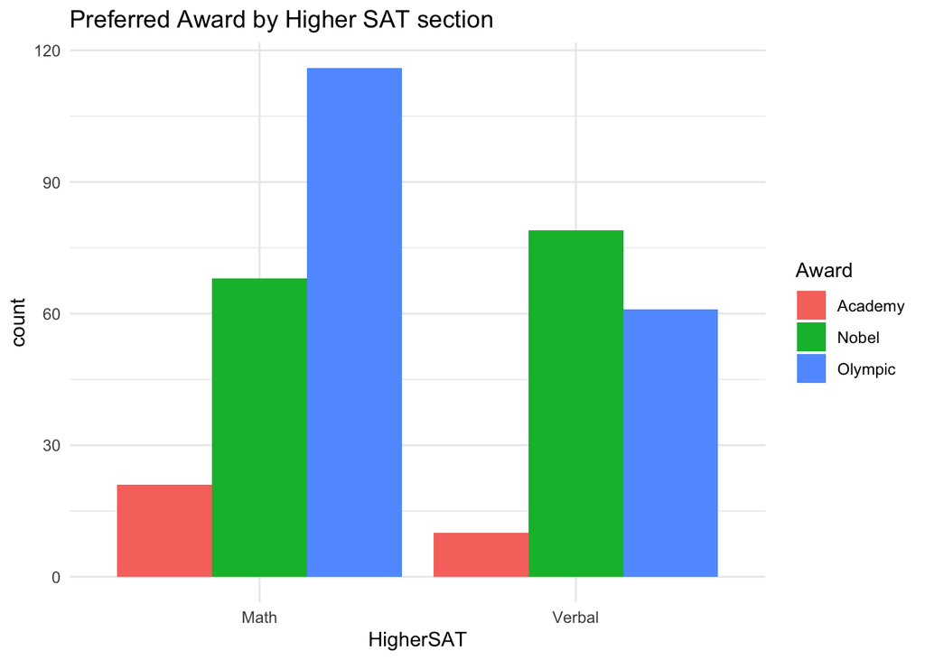

```r
# Use ggplot to make a double-bar plot
ggplot(sat_award, aes(x=HigherSAT, fill=Award)) +
  geom_bar(position = "dodge") +
  labs(title="Preferred Award by Higher SAT section") +
  theme_minimal()
```

#### **Write your insights from the double barplot here:**

Math has a preference for Olympic award whereas Verbal has a less obvious favoured award with Nobel edging out Olympic but not by much. Academy has an affinity towards Math but this is slight as well.